# High Performance Loops in R

Adapted from Roz Dakin’s https://github.com/rozdakin/R_loops_demo

February 11, 2016

## Getting Started

Install and load the following packages:

- gapminder
- dplyr
- microbenchmark

The for loop is used in the following form:

> for(counter) {#action steps}

### Loops Two Ways

1. Loop over indices e.g.:

```r
for(i in 1:10){
    print(i)
}
```

2. Loop over elements of a data structure e.g.:

```r
for(i in head(gapminder$country)) {
  print(i)
}
```

- Related: Loop over names/levels of a factor

```r
for(i in levels(gapminder$country)){
  print(i)
}
```

## Why Loop?

### 1. Resampling Statistics or Simulation (e.g. permutation tests, bootstrapping)

In the following example, we will simulate the central limit theorem by randomly sampling and taking the mean (over 10000 iterations) from a poisson distribution.

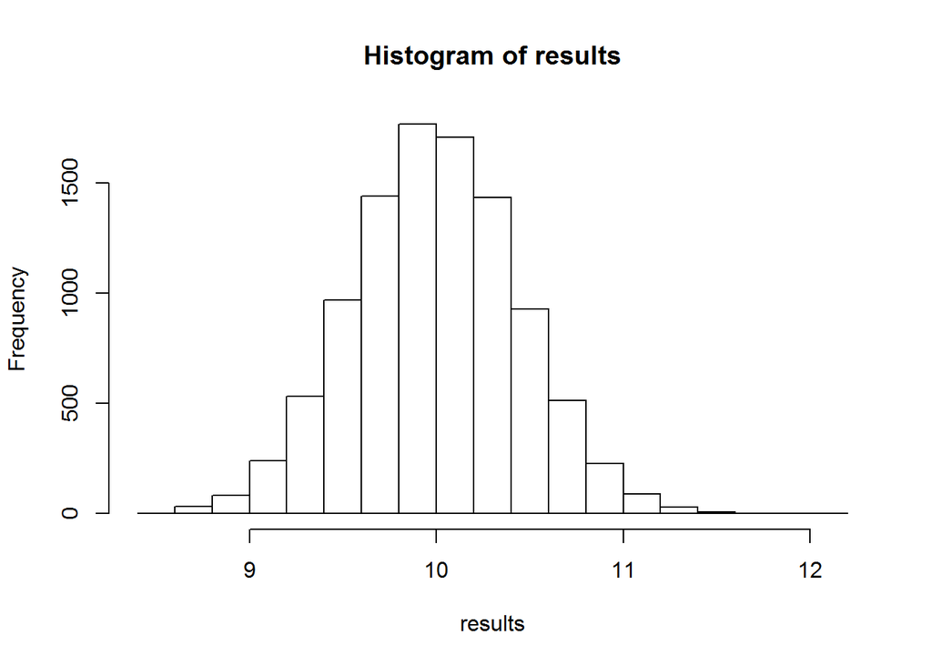

```r
results <- rep(NA, 10000)
for(i in 1:10000){
    a <- rpois(50, lambda=10)
    results[i] <-mean(a)
}
hist(results)
```

Bootstrapping: Resampling with replacement to determine confidence intervals on a statistic, e.g. the mean. Let’s get CIs on the mean of the gdpPercap factor of gapminder. The basic steps involve:

1. Sampling **with replacement**.
2. Calculating the statistic you wish from this sample you’ve obtained.
3. Repeat over x iterations (generally >1000)
4. Estimate sample distribution to determine confidence intervals for statistic of interest.

```r
gdpresults <- rep(NA, 10000)
for(i in 1:10000){
    resample <- sample(gapminder$gdpPercap, replace=T)
    gdpresults[i] <- mean(resample)
}
quantile(gdpresults, c(0.025, 0.975)) # get 95% CI
```

```
##     2.5%    97.5%
## 6758.579 7687.294
```

### 2. Processing/Analyzing/Visualizing large and/or distributed datasets

You may want to perform the same analysis on different subsets/columns of a dataframe/list. This is particularly useful if the analysis has multiple components.

```r
#loop over subsets
countries <- levels(gapminder$country)
results <- rep(NA, length(countries))
for(i in 1:length(countries)){
    mod <- lm(lifeExp ~ gdpPercap, subset(gapminder, country==countries[i]))
    results[i]<-summary(mod)$r.squared
}

#loop over certain columns (lm on column ~ year)
responses <- names(gapminder)[4:6]
results <- rep(NA, length(responses))
for(i in 1:length(responses)){
    myformula <- paste(responses[i],'~year')
    mod <- lm(as.formula(myformula), data=gapminder)
    results[i]<-summary(mod)$r.squared
}
results[1:3]
```

```
## [1] 0.18975714 0.00677462 0.05167350
```

We can make and save lots of separate plots. First, create an empty folder and set it as your working directory. The loop below will generate many plots in that folder.

```r
for(i in 1:length(countries)){
    mypath <- file.path(getwd(), paste(countries[i], '_', paste('00',i,sep=''), ".jpg", sep = ""))
    jpeg(file=mypath, width=4, height=3.5, units='in', res=150)
    par(las=1, bty='n', family='Times', tck=0.02)
    plot(gdpPercap~year,subset(gapminder, country==countries[i]), xlab='year', ylab='gdp per capita (units)', type='l', ylim=c(1,10000))
    dev.off()
}
```

### Instead of For Loops…

While the concept of for looping is very powerful, it is often not the best choice available.

Here you are attempting to create a new column with rounded values of a column using a for loop. (Don’t do this!)

```r
for(i in 1:length(gapminder$pop)){
    gapminder$popround[i] <- round(gapminder$pop[i], -3)
}
head(gapminder)
```

```
## Source: local data frame [6 x 7]
##
##       country continent  year lifeExp      pop gdpPercap popround
##        (fctr)    (fctr) (int)   (dbl)    (int)     (dbl)    (dbl)
## 1 Afghanistan      Asia  1952  28.801  8425333  779.4453  8425000
## 2 Afghanistan      Asia  1957  30.332  9240934  820.8530  9241000
## 3 Afghanistan      Asia  1962  31.997 10267083  853.1007 10267000
## 4 Afghanistan      Asia  1967  34.020 11537966  836.1971 11538000
## 5 Afghanistan      Asia  1972  36.088 13079460  739.9811 13079000
## 6 Afghanistan      Asia  1977  38.438 14880372  786.1134 14880000
```

Do this instead (vectorized!)

```r
gapminder$popround <- round(gapminder$pop, -3)
```

**Recoding Values**

Here we want to change all values of iris’ Group Value to 1 if Sepal Length is between 5 and 6, and set to 2 if greater than or equal to 6 (and set to 0 otherwise). Don’t do this:

```r
iris$sep.group <- 0
for (i in 1:length(iris$Sepal.Length)){
    if(iris$Sepal.Length[i] > 5 & iris$Sepal.Length[i] < 6){
        iris$sep.group[i] <- 1
    }
    if(iris$Sepal.Length[i] >= 6){
        iris$sep.group[i] <- 2
    }
}
head(iris)
```

```
##   Sepal.Length Sepal.Width Petal.Length Petal.Width Species sep.group
## 1          5.1         3.5          1.4         0.2  setosa         1
## 2          4.9         3.0          1.4         0.2  setosa         0
## 3          4.7         3.2          1.3         0.2  setosa         0
## 4          4.6         3.1          1.5         0.2  setosa         0
## 5          5.0         3.6          1.4         0.2  setosa         0
## 6          5.4         3.9          1.7         0.4  setosa         1
```

It is more efficient to use `ifelse(<condition>, <yes>, <no>)` which can also be nested:

```r
iris$sep.group <- ifelse(iris$Sepal.Length > 6, 2, ifelse(iris$Sepal.Length > 5, 1, 0))
head(iris)
```

```
##   Sepal.Length Sepal.Width Petal.Length Petal.Width Species sep.group
## 1          5.1         3.5          1.4         0.2  setosa         1
## 2          4.9         3.0          1.4         0.2  setosa         0
## 3          4.7         3.2          1.3         0.2  setosa         0
## 4          4.6         3.1          1.5         0.2  setosa         0
## 5          5.0         3.6          1.4         0.2  setosa         0
## 6          5.4         3.9          1.7         0.4  setosa         1
```

Do not use for loops to apply summary functions (mean, max, min etc.) to subsets of your data.

```r
countries <- levels(gapminder$country)
cmeans <- rep(NA, length(countries))
for(i in 1:length(countries)){
    data <- subset(gapminder, country==countries[i])
    cmeans[i] <- mean(data$pop)
}
head(cmeans)
```

```
## [1] 15823715  2580249 19875406  7309390 28602240 14649313
```

dplyr has a summarise() function for this purpose

```r
by.country <- group_by(gapminder, country)
summ.country <- summarise(by.country, meanpop = round(mean(pop)/1000,-3))
head(summ.country)
```

```
## Source: local data frame [6 x 2]
##
##       country meanpop
##        (fctr)   (dbl)
## 1 Afghanistan   16000
## 2     Albania    3000
## 3     Algeria   20000
## 4      Angola    7000
## 5   Argentina   29000
## 6   Australia   15000
```

#### The Apply Functions

In base R, the apply family is very useful in place of writing your own loops:

```r
help("apply")
apply(gapminder[,4:6], 2, 'mean') # applied to columns
head(apply(iris[,1:4], 1, 'sum')) #applied to rows

help(tapply) # good for dataframes or separate vectors which can be ragged (different sizes)
tapply(gapminder$lifeExp, gapminder$country, FUN='mean')
# tapply(vector, factor, function)
tapply(gapminder$lifeExp, gapminder$country, FUN=function(x) round(mean(x),-1))
# can write your own functions to bue used with apply & co. can be done inside or outside the loop
```

Note that you can write your own function to be used with the apply family, either inside or outside the loop.

In this example, we will use tapply() to normalize all the values of gapminder$pop based on country. Then we will use lapply() which works on lists to apply our functions.

```r
poppercent <- tapply(gapminder$pop, gapminder$country, function(x) x/max(x))
#this will give a list of lists, ordered by country
head(poppercent)
#now we can use lapply on this list
lapply(poppercent, mean) #to find the mean
lapply(poppercent, function(x) sd(x)/sqrt(length(x))) #to find the SEM
```

### Speed Up Your Loops

#### How to Time Your Code

> 1. Enclose in system.time()

> ```r
> system.time(mean(1:1000000))
> ```

> ```
> ##    user  system elapsed
> ##    0.02    0.00    0.01
> ```

> 2. For big chunks, determine the processing time of code with proc.time()

> ```r
> pmt <- proc.time()
> mean(1:1000000)
> ```

> ```
> ## [1] 500000.5
> ```

> ```r
> proc.time() - pmt
> ```

> ```
> ##    user  system elapsed
> ##       0       0       0
> ```

> 3. Using microbenchmark, it will be a more accurate estimate as it samples the action many times (default = 100, but can change as desired). This will take longer but can be useful if choosing between two methods that you will use extensively.

> ```r
> microbenchmark(mean(1:1000000))
> ```

> ```
> ## Unit: milliseconds
> ##           expr      min     lq     mean   median       uq      max neval
> ##  mean(1:1e+06) 2.144687 2.5918 11.58111 3.735134 4.797427 47.87291   100
> ```

> You can also pass it multiple things to compare speeds:

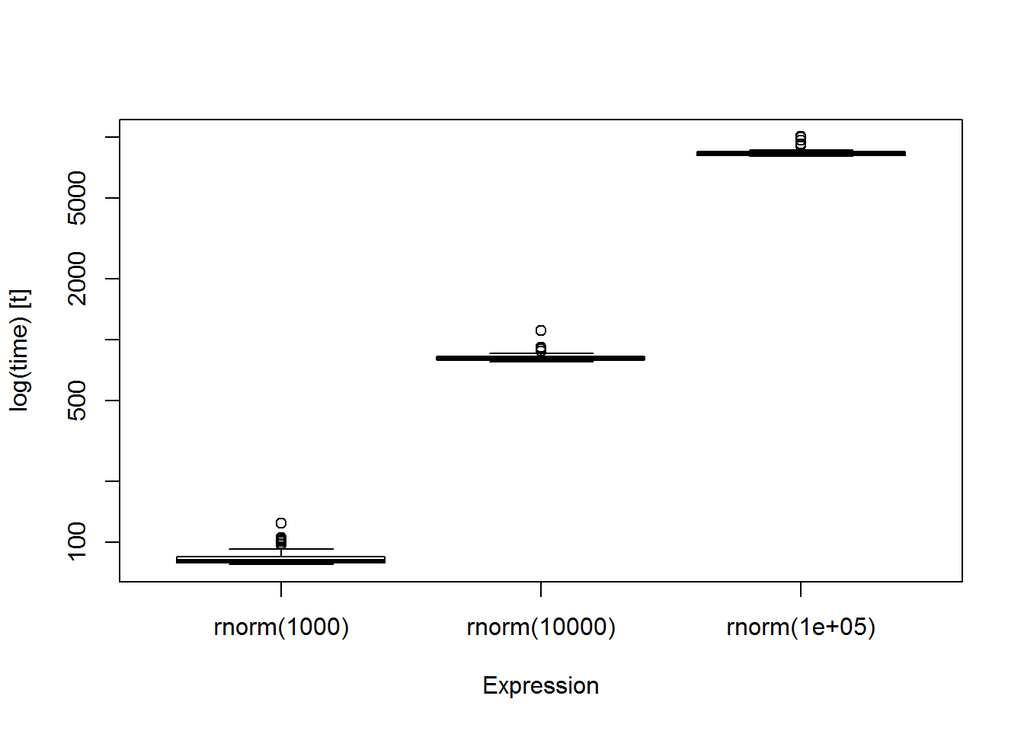

> ```r
> rnormtime <- microbenchmark(rnorm(1000), rnorm(10000), rnorm(100000), times=50)
> boxplot(rnormtime)
> ```

Here are some basic principles to follow when looping:

**1.Initialize your data structures rather than growing them as you loop (avoid appending to a given structure; pre-allocate space instead and then access!)**

Let’s look at an example here of growing vs. pre-allocating/accessing:

```r
hit <- NA
system.time (for(i in 1:100000){if(runif(1) < 0.3) hit[i] <- T})
```

```
##    user  system elapsed
##    1.97    0.04    2.00
```

```r
hit2 <- rep(NA, 100000)
system.time (for(i in 1:100000){if(runif(1) < 0.3) hit2[i] <- T})
```

```
##    user  system elapsed
##    0.22    0.00    0.22
```

**2.Take advantage of vectorized operations when possible and take the work outside of loops.**

Note, sometimes more code is not always a bad thing, especially if your primary goal is time saving in the computations, especially as you begin to work with increasingly large datasets.

Here we will try to denote all years in which lifeExp of a country decreased as a “bad” year.

First with a for loop…

```r
pmt <- proc.time()
gapminder$badyear <- NA
rows <- length(gapminder[,1])
for(i in 2:rows){
  if((gapminder$lifeExp[i] < gapminder$lifeExp[i-1]) & (gapminder$country[i]==gapminder$country[i-1])){
    gapminder$badyear[i] <- 'bad'
  }
}
proc.time() - pmt
summary(factor(gapminder$badyear))
```

[output not shown]

And without:

```r
start <- proc.time()
gapminder$lifeExpnext <- NA
rows <- length(gapminder[,1])
# create a column where, for each year, the next year's lifeExp is indicated
gapminder$lifeExpnext[1:rows-1] <- gapminder$lifeExp[2:rows]
gapminder$countrynext <- NA
# in order to keep track of country (don't want to compare two different countries)
gapminder$countrynext[1:rows-1] <- as.character(gapminder$country[2:rows])
# the vectorized component
gapminder$badyear <- ifelse(gapminder$countrynext==gapminder$country & gapminder$lifeExpnext < gapminder$lifeExp, "bad", NA)
proc.time() - start
```

```
##    user  system elapsed
##       0       0       0
```

**3.Indexing vectors is faster than indexing dataframes.**

```r
#in a dataframe
results <- data.frame(t1=rep(NA,1000), pval=NA)

microbenchmark(
for(i in 1:1000){
  a <- rnorm(50, 10)
  grp <- rep(1:2, each = length(a)/2)
  stat <- t.test(a~grp)
  results$t1[i] <- stat$statistic
  results$pval[i] <- stat$p.value
}, times = 1
)
```

```
## Unit: milliseconds
##                                                                                                                                                                                      expr
##  for (i in 1:1000) {     a <- rnorm(50, 10)     grp <- rep(1:2, each = length(a)/2)     stat <- t.test(a ~ grp)     results$t1[i] <- stat$statistic     results$pval[i] <- stat$p.value }
##       min       lq     mean   median       uq      max neval
##  931.6818 931.6818 931.6818 931.6818 931.6818 931.6818     1
```

```r
#as two vectors
t1 <- rep(NA, 1000)
pval <- rep(NA, 1000)

microbenchmark(
  for(i in 1:1000){
    a <- rnorm(50, 10)
    grp <- rep(1:2, each = length(a)/2)
    stat <- t.test(a ~ grp)
    t1[i] <- stat$statistic
    pval[i] <- stat$p.value
  }, times = 1
)
```

```
## Unit: milliseconds
##                                                                                                                                                                      expr
##  for (i in 1:1000) {     a <- rnorm(50, 10)     grp <- rep(1:2, each = length(a)/2)     stat <- t.test(a ~ grp)     t1[i] <- stat$statistic     pval[i] <- stat$p.value }
##       min       lq     mean   median       uq      max neval
##  903.2607 903.2607 903.2607 903.2607 903.2607 903.2607     1
```

```r
#Small difference, but can save time on larger datasets
```

### Resources (free online!)

Patrick Burns’ R Inferno: http://www.burns-stat.com/pages/Tutor/R_inferno.pdf  
Hadley Wickham’s Advanced R (esp. Functionals and Profiling): http://adv-r.had.co.nz/